# HW3

Author

Brandy Recio

1. **How many abstracts are associated with each search term? Tokenize the abstracts and count the number of each token. Do you see anything interesting? What are the 5 most common tokens for each search term?**

   ```r
   # load packages
   library(tidyverse)
   library(tidytext)
   library(kableExtra)
   library(dplyr)
   library(knitr)

   #Abstracts per term
   pubmed %>%
     filter(!is.na(abstract) & abstract != "") %>%
     count(term, name = "n_abstracts") %>%
     arrange(desc(n_abstracts)) %>%
     kable(col.names = c("Term", "Number of Abstracts"))
   ```

   | Term | Number of Abstracts |
   | --- | --- |
   | covid | 981 |
   | prostate cancer | 787 |
   | preeclampsia | 780 |
   | cystic fibrosis | 376 |
   | meningitis | 317 |

   There were 981 abstracts associated with covid, 787 with prostate cancer, 780 with preeclampsia, 376 with cystic fibrosis, and 317 with meningitis.

```r
#Number of tokens after tokenizing
top20 <- pubmed %>%
  unnest_tokens(word, abstract) %>%
  count(word, sort = TRUE) %>%
  slice_head(n = 20)

knitr::kable(top20,
             col.names = c("Word", "Count"),
             caption = "Top 20 Most Frequent Words")
```

Top 20 Most Frequent Words

| Word | Count |
| --- | --- |
| the | 28126 |
| of | 24760 |
| and | 19993 |
| in | 14653 |
| to | 10920 |
| a | 8245 |
| with | 8038 |
| covid | 7275 |
| 19 | 7080 |
| is | 5649 |
| for | 5492 |
| patients | 4674 |
| cancer | 3999 |
| prostate | 3832 |
| was | 3315 |
| that | 3226 |
| were | 3226 |
| as | 3159 |
| this | 3158 |
| are | 2833 |

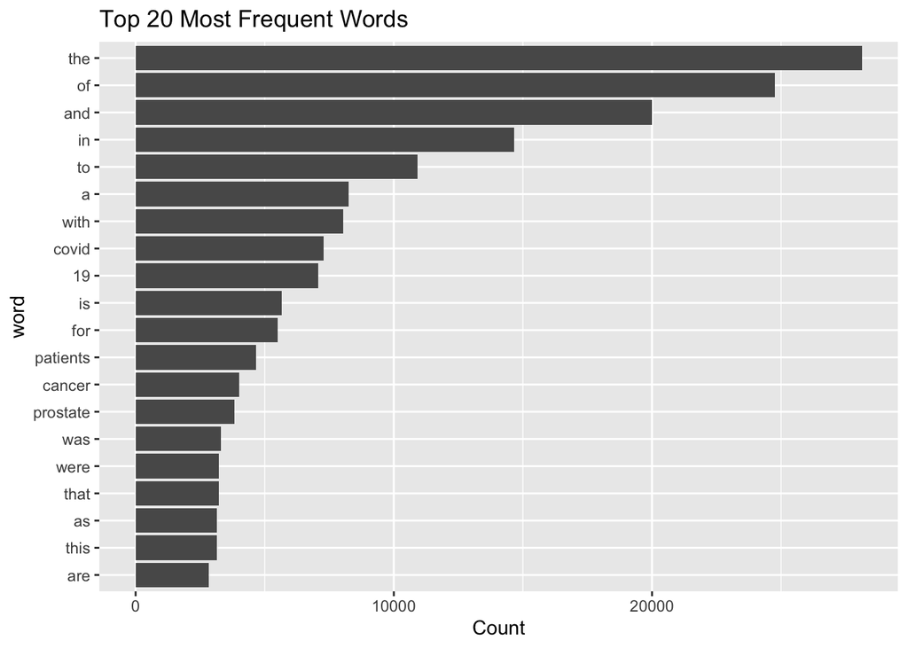

```r
ggplot(top20, aes(x = reorder(word, n), y = n)) +
  geom_col() +
  coord_flip() +
  labs(x = "word", y = "Count", title = "Top 20 Most Frequent Words")
```

After tokenizing, I realized that the majority of token are stop words.

```r
# Top 5 tokens per term
top5_term <- pubmed %>%
  unnest_tokens(word, abstract) %>%
  # Optional: remove stopwords
  # anti_join(stop_words, by = "word") %>%
  count(term, word, sort = TRUE) %>%
  group_by(term) %>%
  slice_max(n, n = 5, with_ties = FALSE) %>%
  arrange(term, desc(n)) %>%
  ungroup()

# Table
top5_term %>%
  rename(Term = term, Word = word, Count = n) %>%
  kbl(caption = "Top 5 Tokens per Term") %>%
  kable_styling(full_width = FALSE)
```

Top 5 Tokens per Term

| Term | Word | Count |
| --- | --- | --- |
| covid | the | 9741 |
| covid | of | 7668 |
| covid | covid | 7275 |
| covid | 19 | 7035 |
| covid | and | 6861 |
| cystic fibrosis | the | 2677 |
| cystic fibrosis | of | 2304 |
| cystic fibrosis | and | 1777 |
| cystic fibrosis | in | 1497 |
| cystic fibrosis | to | 1011 |
| meningitis | the | 2489 |
| meningitis | of | 2269 |
| meningitis | and | 1683 |
| meningitis | in | 1322 |
| meningitis | a | 830 |
| preeclampsia | the | 7119 |
| preeclampsia | of | 6837 |
| preeclampsia | and | 5255 |
| preeclampsia | in | 3869 |
| preeclampsia | to | 2651 |
| prostate cancer | the | 6100 |
| prostate cancer | of | 5682 |
| prostate cancer | and | 4417 |
| prostate cancer | cancer | 3840 |
| prostate cancer | prostate | 3832 |

Here in this table I show the top 5 most common token per term. The majority are stops words, but there are also words such as “covid”, “19”, “cancer”, and “prostate” that are associated with their respective term.

2. **Does removing stop words change what tokens appear as the most frequent? What are the 5 most common tokens for each search term after removing stop words?**

```r
top5 <- pubmed %>%
  unnest_tokens(word, abstract) %>%
  anti_join(stop_words, by = "word") %>%
  filter(!grepl("^[0-9]+$", word)) %>%
  count(term, word, sort = TRUE) %>%
  group_by(term) %>%
  slice_max(n, n = 5, with_ties = FALSE) %>%
  ungroup()

top5 %>%
  rename(Term = term, Word = word, Count = n) %>%
  kbl(caption = "Top 5 words per term") %>%
  kable_styling(full_width = FALSE)
```

Top 5 words per term

| Term | Word | Count |
| --- | --- | --- |
| covid | covid | 7275 |
| covid | patients | 2293 |
| covid | disease | 943 |
| covid | pandemic | 800 |
| covid | coronavirus | 647 |
| cystic fibrosis | fibrosis | 867 |
| cystic fibrosis | cystic | 862 |
| cystic fibrosis | cf | 625 |
| cystic fibrosis | patients | 586 |
| cystic fibrosis | disease | 400 |
| meningitis | patients | 446 |
| meningitis | meningitis | 429 |
| meningitis | meningeal | 219 |
| meningitis | csf | 206 |
| meningitis | clinical | 187 |
| preeclampsia | pre | 2038 |
| preeclampsia | eclampsia | 2005 |
| preeclampsia | preeclampsia | 1863 |
| preeclampsia | women | 1196 |
| preeclampsia | pregnancy | 969 |
| prostate cancer | cancer | 3840 |
| prostate cancer | prostate | 3832 |
| prostate cancer | patients | 934 |
| prostate cancer | treatment | 926 |
| prostate cancer | disease | 652 |

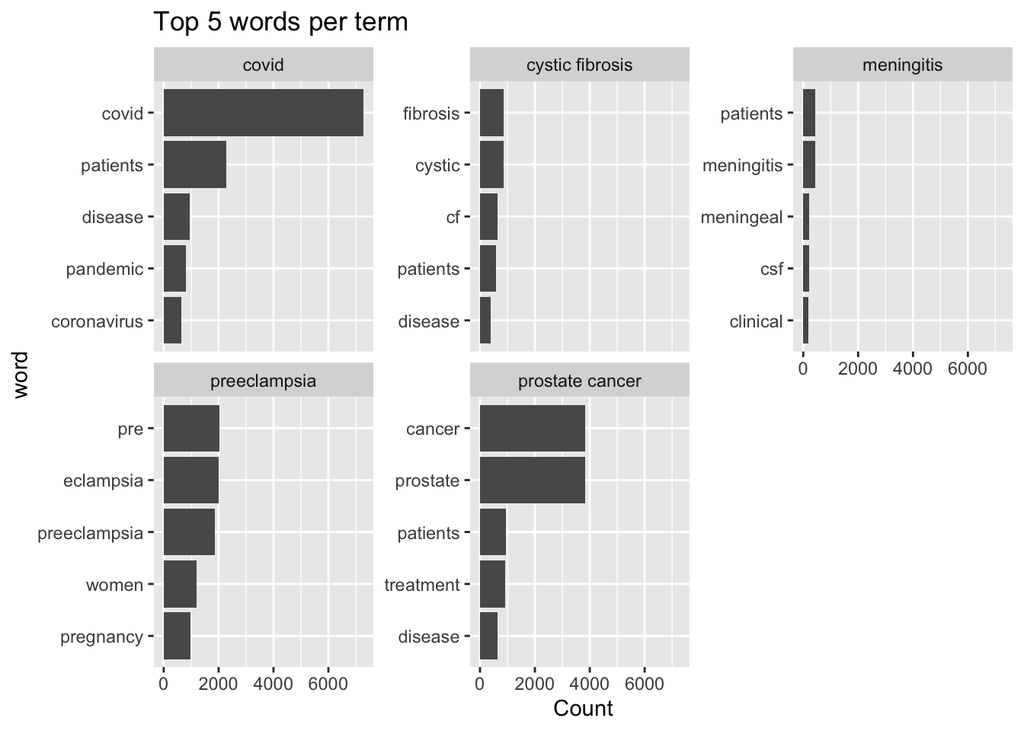

```r
top5 %>%
  mutate(word = reorder_within(word, n, term)) %>%
  ggplot(aes(x = word, y = n)) +
  geom_col() +
  coord_flip() +
  facet_wrap(~ term, scales = "free_y") +
  tidytext::scale_x_reordered() +
  labs(x = "word", y = "Count",
       title = "Top 5 words per term")
```

After removing the stop words, I realized that the most frequent words are related to their respective term, which are more relevant and gives more information about what the abstracts are about.

3. **Tokenize the abstracts into bigrams. Find the 10 most common bigrams and visualize them.**

```r
top10_bigrams <- pubmed %>%
  unnest_tokens(bigram, abstract, token = "ngrams", n = 2) %>%
  separate(bigram, into = c("w1", "w2"), sep = " ", remove = FALSE) %>%
  anti_join(stop_words, by = c("w1" = "word")) %>%
  anti_join(stop_words, by = c("w2" = "word")) %>%
  unite(bigram, w1, w2, sep = " ", remove = TRUE) %>%
  count(bigram, sort = TRUE) %>%
  top_n(10, n)

top10_bigrams %>%
  rename(Bigram = bigram, Count = n) %>%
  kbl(caption = "Top 10 Most Frequent Bigrams") %>%
  kable_styling(full_width = FALSE)
```

Top 10 Most Frequent Bigrams

| Bigram | Count |
| --- | --- |
| covid 19 | 6969 |
| prostate cancer | 3222 |
| pre eclampsia | 1854 |
| cystic fibrosis | 860 |
| 19 patients | 447 |
| 19 pandemic | 419 |
| coronavirus disease | 361 |
| 95 ci | 322 |
| sars cov | 317 |
| cov 2 | 299 |

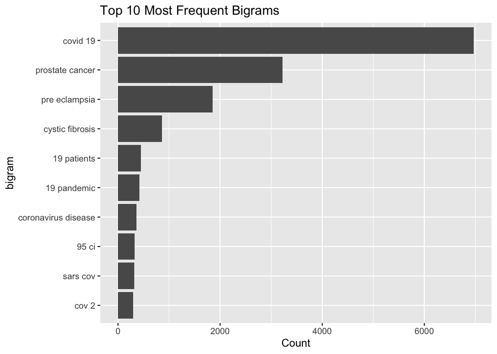

```r
top10_bigrams %>%
  ggplot(aes(x = reorder(bigram, n), y = n)) +
  geom_col() +
  coord_flip() +
  labs(x = "bigram", y = "Count", title = "Top 10 Most Frequent Bigrams")
```

The top 10 bigrams after removing stop words are mostly related to covid-19 contexts ( 6 out of 10)

4. **Calculate the TF-IDF value for each word-search term combination (here you want the search term to be the “document”). What are the 5 tokens from each search term with the highest TF-IDF value? How are the results different from the answers you got in Question 1?**

```r
term_word_counts <- pubmed %>%
  unnest_tokens(word, abstract) %>%
  anti_join(stop_words, by = "word") %>%
  filter(!str_detect(word, "^[0-9]+$")) %>%
  count(term, word, name = "n", sort = TRUE)

tfidf_tbl <- term_word_counts %>%
  bind_tf_idf(word, term, n) %>%
  arrange(term, desc(tf_idf))

# Top 5 TF-IDF tokens per term
top5_tfidf <- tfidf_tbl %>%
  group_by(term) %>%
  slice_max(tf_idf, n = 5, with_ties = FALSE) %>%
  ungroup() %>%
  select(term, word, n, tf, idf, tf_idf)

top5_tfidf %>%
  rename(Term = term, Token = word, Count = n, TF = tf, IDF = idf, `TF-IDF` = tf_idf) %>%
  kbl(caption = "Top 5 tokens per search term by TF-IDF") %>%
  kable_styling(full_width = FALSE)
```

Top 5 tokens per search term by TF-IDF

| Term | Token | Count | TF | IDF | TF-IDF |
| --- | --- | --- | --- | --- | --- |
| covid | covid | 7275 | 0.0721733 | 1.6094379 | 0.1161585 |
| covid | pandemic | 800 | 0.0079366 | 1.6094379 | 0.0127734 |
| covid | coronavirus | 647 | 0.0064187 | 1.6094379 | 0.0103305 |
| covid | sars | 372 | 0.0036905 | 1.6094379 | 0.0059397 |
| covid | cov | 334 | 0.0033135 | 1.6094379 | 0.0053329 |
| cystic fibrosis | cf | 625 | 0.0242089 | 0.9162907 | 0.0221823 |
| cystic fibrosis | fibrosis | 867 | 0.0335825 | 0.5108256 | 0.0171548 |
| cystic fibrosis | cystic | 862 | 0.0333889 | 0.5108256 | 0.0170559 |
| cystic fibrosis | cftr | 86 | 0.0033311 | 1.6094379 | 0.0053613 |
| cystic fibrosis | sweat | 83 | 0.0032149 | 1.6094379 | 0.0051742 |
| meningitis | meningitis | 429 | 0.0172462 | 1.6094379 | 0.0277567 |
| meningitis | meningeal | 219 | 0.0088040 | 1.6094379 | 0.0141695 |
| meningitis | pachymeningitis | 149 | 0.0059899 | 1.6094379 | 0.0096405 |
| meningitis | csf | 206 | 0.0082814 | 0.9162907 | 0.0075882 |
| meningitis | meninges | 106 | 0.0042613 | 1.6094379 | 0.0068583 |
| preeclampsia | eclampsia | 2005 | 0.0266803 | 1.6094379 | 0.0429403 |
| preeclampsia | preeclampsia | 1863 | 0.0247907 | 1.6094379 | 0.0398992 |
| preeclampsia | pregnancy | 969 | 0.0128944 | 0.5108256 | 0.0065868 |
| preeclampsia | maternal | 797 | 0.0106056 | 0.5108256 | 0.0054176 |
| preeclampsia | gestational | 191 | 0.0025416 | 1.6094379 | 0.0040906 |
| prostate cancer | prostate | 3832 | 0.0576943 | 1.6094379 | 0.0928554 |
| prostate cancer | androgen | 305 | 0.0045921 | 1.6094379 | 0.0073906 |
| prostate cancer | psa | 282 | 0.0042458 | 1.6094379 | 0.0068333 |
| prostate cancer | prostatectomy | 215 | 0.0032370 | 1.6094379 | 0.0052098 |
| prostate cancer | castration | 148 | 0.0022283 | 1.6094379 | 0.0035863 |

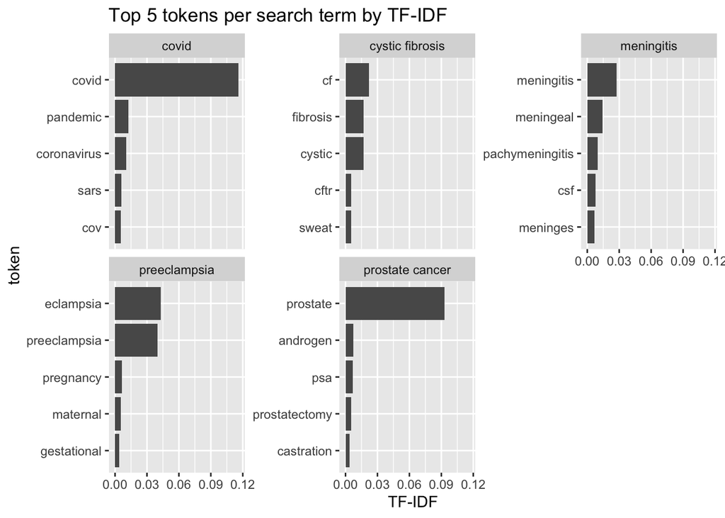

```r
top5_tfidf %>%
  mutate(word = reorder_within(word, tf_idf, term)) %>%
  ggplot(aes(x = word, y = tf_idf)) +
  geom_col() +
  coord_flip() +
  facet_wrap(~ term, scales = "free_y") +
  tidytext::scale_x_reordered() +
  labs(x = "token", y = "TF-IDF",
       title = "Top 5 tokens per search term by TF-IDF")
```

Compared to question 1 results where token were more broad to all terms, TF-IDF outputs tokens that are more specific to their respective terms.

## **Sentiment Analysis**

5. **Perform a sentiment analysis using the NRC lexicon. What is the most common sentiment for each search term? What if you remove `"positive"` and `"negative"` from the list?**

```r
# Sentiments
sent_counts <- pubmed %>%
  unnest_tokens(word, abstract) %>%
  anti_join(tidytext::stop_words, by = "word") %>%
  filter(!str_detect(word, "^[0-9]+$")) %>%
  inner_join(tidytext::get_sentiments("nrc"), by = "word") %>%
  count(term, sentiment, name = "n", sort = TRUE)

# Most common sentiment per term
top_sent <- sent_counts %>%
  group_by(term) %>%
  slice_max(n, n = 1, with_ties = TRUE) %>%
  ungroup()

top_sent %>%
  rename(Term = term, Sentiment = sentiment, Count = n) %>%
  kbl(caption = "Most common NRC sentiment per search term") %>%
  kable_styling(full_width = FALSE)
```

Most common NRC sentiment per search term

| Term | Sentiment | Count |
| --- | --- | --- |
| covid | positive | 9254 |
| cystic fibrosis | positive | 2564 |
| meningitis | negative | 1959 |
| preeclampsia | positive | 7603 |
| prostate cancer | negative | 8799 |

```r
# Repeat excluding "positive" and "negative"
top_sent_no_pn <- sent_counts %>%
  filter(!sentiment %in% c("positive", "negative")) %>%
  group_by(term) %>%
  slice_max(n, n = 1, with_ties = TRUE) %>%
  ungroup()

top_sent_no_pn %>%
  rename(Term = term, Sentiment = sentiment, Count = n) %>%
  kbl(caption = "Most common NRC sentiment per search term excluding 'positive' and 'negative'") %>%
  kable_styling(full_width = FALSE)
```

Most common NRC sentiment per search term excluding 'positive' and 'negative'

| Term | Sentiment | Count |
| --- | --- | --- |
| covid | fear | 7373 |
| cystic fibrosis | disgust | 1714 |
| meningitis | fear | 1371 |
| preeclampsia | anticipation | 4555 |
| prostate cancer | fear | 8039 |

Negative and positive connotations may not reflect the true sentiments in the abstract as it is very arbitrary what counts as “negative” and “positive”, so more detailed information was needed. After excluding negative and positive sentiments and only leave more specific emotions, then we have a better idea of the type of sentiments the literature is about. I noticed that fear and disgust were before “positive” sentiments which was misleading. In my opinion, sentiments are more abstract rather than factual, so sentiments in this case are not appropiate for scientific literature.

6. **Now perform a sentiment analysis using the AFINN lexicon to get an average positivity score for each abstract (hint: you may want to create a variable that indexes, or counts, the abstracts). Create a visualization that shows these scores grouped by search term. Are any search terms noticeably different from the others?**

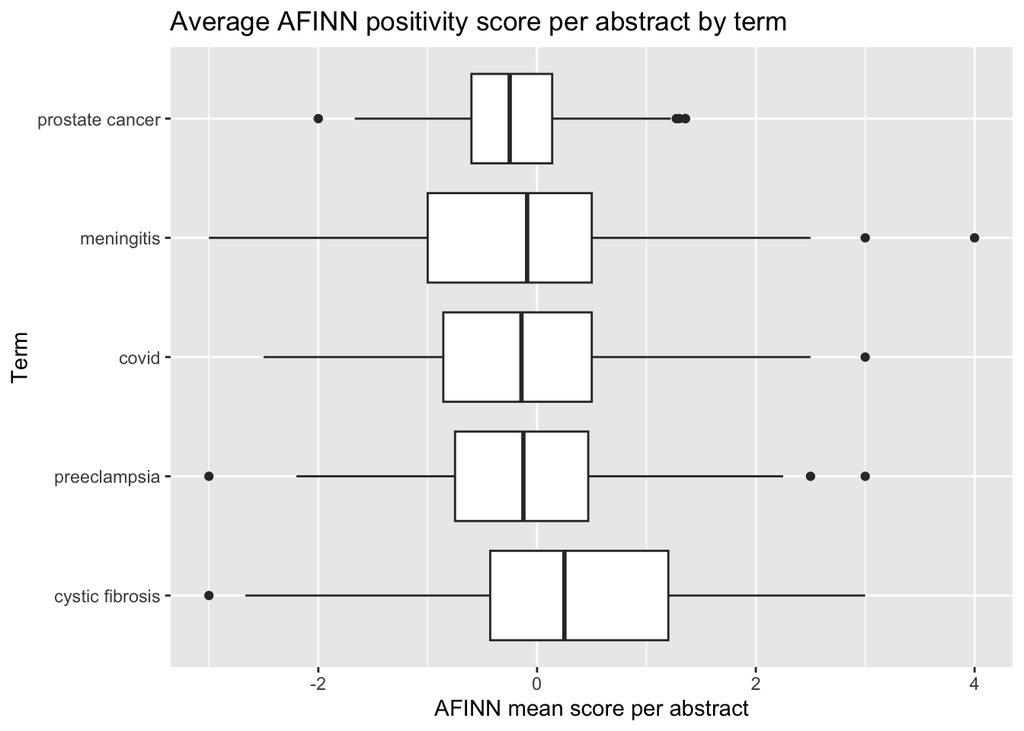

```r
afinn <- get_sentiments("afinn")
afinn_means <- pubmed %>%
  mutate(abstract_id = row_number()) %>%
  unnest_tokens(word, abstract) %>%
  inner_join(afinn, by = "word") %>%
  group_by(term, abstract_id) %>%
  summarise(mean_score = mean(value), .groups = "drop") %>%
  right_join(pubmed %>% mutate(abstract_id = row_number()) %>% select(term, abstract_id), by = c("term","abstract_id")) %>%
  mutate(mean_score = replace_na(mean_score, 0))

ggplot(afinn_means,
       aes(x = fct_reorder(term, mean_score, .fun = mean, .desc = TRUE),
           y = mean_score)) +
  geom_boxplot() +
  coord_flip() +
  labs(x = "Term", y = "AFINN mean score per abstract",
       title = "Average AFINN positivity score per abstract by term")
```

I noticed that cystic fibrosis is the only term with an average positive AFINN score while prostate cancer was the most negative.